# PART A- Multi-Label Classifier

**DOMAIN**: Digital content management

**CONTEXT**: Classification is probably the most popular task that you would deal with in real life. Text in the form of blogs, posts, articles, etc. are written every second. It is a challenge to predict the information about the writer without knowing about him/her. We are going to create a classifier that predicts multiple features of the author of a given text. We have designed it as a `Multi label classification` problem.

**DATA DESCRIPTION**: Over **600,000** posts from more than **19 thousand** bloggers **The Blog Authorship Corpus** consists of the collected posts of **19,320** bloggers gathered from **blogger.com** in August 2004. The corpus incorporates a total of **681,288** posts and over **140 million** words - or approximately **35** posts and **7250 words per person**. Each blog is presented as a separate file, the name of which indicates a blogger id# and the blogger’s self-provided gender, age, industry, and astrological sign. (All are labelled for gender and age but for many, industry and/or sign is marked as unknown.) All bloggers included in the corpus fall into one of three age groups:

- 8240 "10s" blogs (ages 13-17),
- 8086 "20s" blogs(ages 23-27) and
- 2994 "30s" blogs (ages 33-47)
- For each age group, there is an equal number of male and female bloggers. Each blog in the corpus includes at least 200 occurrences of common English words. All formatting has been stripped with two exceptions. Individual posts within a single blogger are separated by the date of the following post and links within a post are denoted by the label url link.

**PROJECT OBJECTIVE**: To build a NLP classifier which can use input text parameters to determine the label/s of the blog. Specific to this case study, you can consider the text of the blog: **text** feature as independent variable and **topic** as dependent variable.

## Importing the necessary libraries

```python
!pip install spacy-langdetect --quiet
```

```python
import numpy as np # mathematical manipulations
import pandas as pd # data manipulations

# for visualisation
import matplotlib.pyplot as plt
%matplotlib inline
import seaborn as sns

# splitting into train and test sets and searching for hyperparameter tuning
from sklearn.model_selection import train_test_split,RandomizedSearchCV,GridSearchCV

# for dealing with non-english words
import spacy
from spacy_langdetect import LanguageDetector

# RegEx to detect patterns
import re

# Remove stopwords
import nltk
from nltk.corpus import stopwords
nltk.download('stopwords', quiet=True)

# convert text to vectors
from sklearn.feature_extraction.text import CountVectorizer,TfidfVectorizer

# pre-processing modules
from sklearn.preprocessing import LabelEncoder

# ML model libraries
from sklearn.svm import SVC
from sklearn.linear_model import LogisticRegression
from sklearn.neighbors import KNeighborsClassifier

# various model performance measures
from sklearn.metrics import confusion_matrix, classification_report,accuracy_score,f1_score,precision_recall_fscore_support

# Neural Network libraries
import tensorflow as tf

# unzipping the data
import zipfile

# ignore warnings
import warnings
warnings.filterwarnings("ignore")

# initialize random number generator
import random
# set the seed for consistent results for multiple runs
seed = 7
np.random.seed(seed)
```

## Importing the data

```python
# move data to current session
!cp '/content/drive/MyDrive/Colab Notebooks/blogs.zip' .
```

```python
# verify whether data is copied
!ls -lrth
```

```
total 1.1G
drwxr-xr-x 1 root root 4.0K Jun  1 13:50 sample_data
drwx------ 5 root root 4.0K Jun 11 04:25 drive
-rw-r--r-- 1 root root 764M Jun 11 09:26 blogtext.csv
-rw------- 1 root root 290M Jun 11 11:26 blogs.zip
```

```python
# loading the zipfile and extracting train data
with zipfile.ZipFile('/content/blogs.zip','r') as zip_ref:
  zip_ref.extractall()
zip_ref.close()
```

```python
# verify whether data is extracted
!ls -lrth
```

```
total 1.1G
drwxr-xr-x 1 root root 4.0K Jun  1 13:50 sample_data
drwx------ 5 root root 4.0K Jun 11 04:25 drive
-rw------- 1 root root 290M Jun 11 11:26 blogs.zip
-rw-r--r-- 1 root root 764M Jun 11 11:26 blogtext.csv
```

```python
# read csv to a dataframe
blogs_df = pd.read_csv('blogtext.csv')
```

```python
# verify data import by sampling randomly
blogs_df.sample(n=7)
```

|  | id | gender | age | topic | sign | date | text |
| --- | --- | --- | --- | --- | --- | --- | --- |
| 42965 | 3304516 | male | 27 | Technology | Pisces | 24,June,2004 | urlLink Do you see the ma... |
| 218209 | 303162 | female | 38 | indUnk | Virgo | 30,May,2004 | Yeah, cause it's obviously a urlLink... |
| 138338 | 2806788 | female | 26 | Marketing | Taurus | 27,January,2004 | (damned tarnished halo showing agai... |
| 643895 | 3682951 | female | 24 | indUnk | Taurus | 18,June,2004 | I suggest that the underground press co... |
| 452608 | 3368641 | male | 39 | Education | Pisces | 18,May,2004 | sometimes when I am quiet and in ... |
| 612496 | 878554 | female | 24 | Accounting | Aquarius | 27,August,2003 | Work sucks arse today and so does my ol... |
| 130729 | 788927 | male | 16 | Communications-Media | Scorpio | 03,October,2002 | Hmm well today, I talked to Rachel, hav... |

## Analyzing data

```python
# check shape of dataset
blogs_df.shape
```

```
(681284, 7)
```

```python
# check data types, records
blogs_df.info()
```

```
<class 'pandas.core.frame.DataFrame'>
RangeIndex: 681284 entries, 0 to 681283
Data columns (total 7 columns):
 #   Column  Non-Null Count   Dtype
---  ------  --------------   -----
 0   id      681284 non-null  int64
 1   gender  681284 non-null  object
 2   age     681284 non-null  int64
 3   topic   681284 non-null  object
 4   sign    681284 non-null  object
 5   date    681284 non-null  object
 6   text    681284 non-null  object
dtypes: int64(2), object(5)
memory usage: 36.4+ MB
```

```python
# checking na values
blogs_df.isna().sum()
```

```
id        0
gender    0
age       0
topic     0
sign      0
date      0
text      0
dtype: int64
```

```python
# checking null values
blogs_df.isnull().sum()
```

```
id        0
gender    0
age       0
topic     0
sign      0
date      0
text      0
dtype: int64
```

```python
def print_value_count(df,column_names):
  '''
  Prints the value counts of variables of a df
  '''
  for col in column_names:
    print(f'*** Values for {col.upper()} ***')
    print(df[col].value_counts())
    print()
```

```python
def pie_chart_and_count_plot(df,col_name):
  '''
  Get the count and pie chart plots for a column for a df
  '''
  # initialising subplots
  figure, ax = plt.subplots(nrows=1, ncols=2)

  # setting figure parameters
  figure.set_figheight(10)
  figure.set_figwidth(20)

  #setting axes titles
  ax[0].set_title(f'Pie Chart of {col_name}')
  ax[1].set_title(f'Count plot of {col_name}')

  # plotting the distribution
  df[col_name].value_counts().plot.pie(ax=ax[0],autopct='%1.1f%%')
  sns.countplot(x=col_name,data=df,ax=ax[1])

  plt.tight_layout()
  plt.show()
```

```
*** Values for GENDER ***
male      345193
female    336091
Name: gender, dtype: int64

*** Values for AGE ***
17    80859
24    80071
23    72889
16    72708
25    67051
26    55312
27    46124
15    41767
14    27400
34    21347
33    17584
35    17462
36    14229
13    13133
37     9317
38     7545
39     5556
40     5016
45     4482
43     4230
41     3738
48     3572
42     2908
46     2733
47     2207
44     2044
Name: age, dtype: int64

*** Values for TOPIC ***
indUnk                     251015
Student                    153903
Technology                  42055
Arts                        32449
Education                   29633
```

[output cut: 36 more lines]

```

*** Values for SIGN ***
Cancer         65048
Aries          64979
Taurus         62561
Libra          62363
Virgo          60399
Scorpio        57161
Pisces         54053
Leo            53811
Gemini         51985
Sagittarius    50036
Aquarius       49687
Capricorn      49201
Name: sign, dtype: int64
```

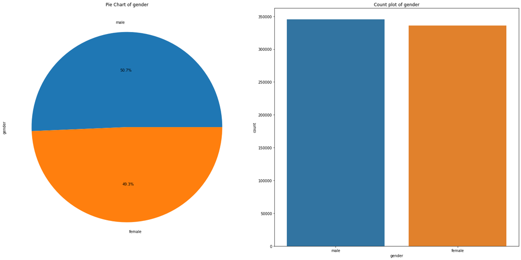

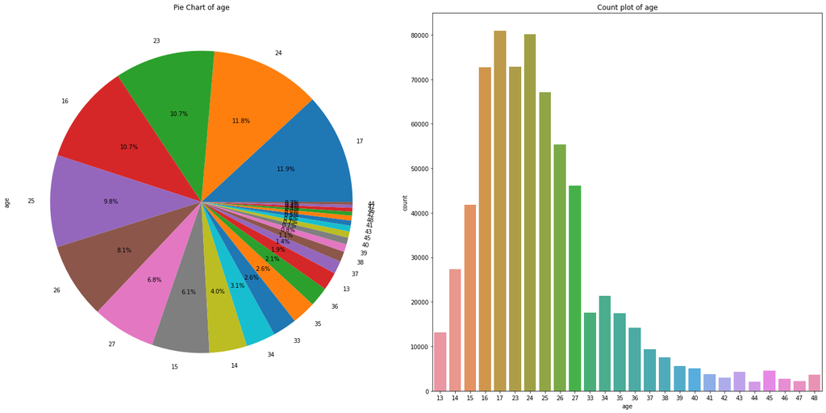

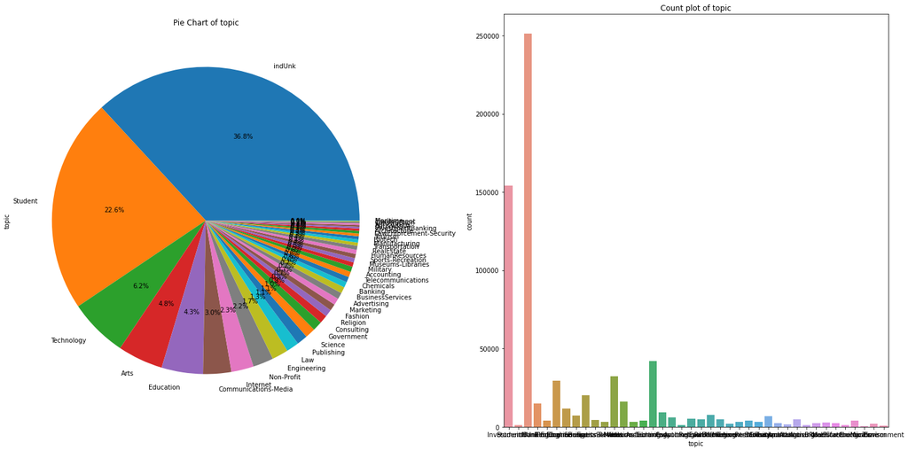

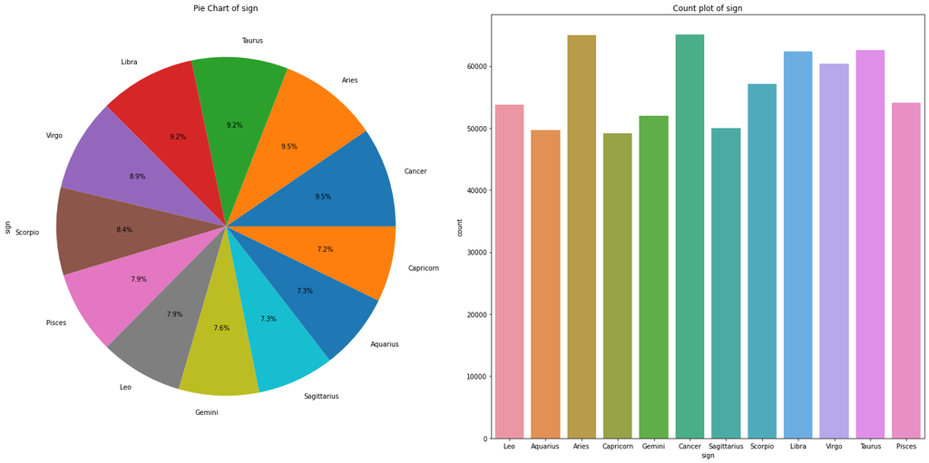

```python
# seeing various values for few variables
columns_for_distr = ['gender', 'age',	'topic',	'sign']

print_value_count(blogs_df,columns_for_distr)

for col in columns_for_distr:
  pie_chart_and_count_plot(blogs_df,col)
  print('*'*40)
```

```python
blogs_df = blogs_df.head(5000) # remove after writing code and load entire data or based on machine load the samples
```

```python
nlp = spacy.load('en') # load english detector
nlp.add_pipe(LanguageDetector(), name='language_detector', last=True) # add the detector to pileine
```

```python
def english_language_detector(text):
  '''
  Detects average language of the text and returns it.
  '''
  try:
    doc = nlp(text)
    # document level language detection. Think of it like average language of the document!
    return doc._.language['language']
  except:
    # in case of an exception, it's not english
    return 'could not detect'
```

```python
# detect average language of text
blogs_df['text_language'] = blogs_df['text'].apply(english_language_detector)
```

```python
print('*** Values for TEXT_LANGUAGE ***')
print(blogs_df['text_language'].value_counts())
```

```
*** Values for TEXT_LANGUAGE ***
en         4724
af           28
nl           28
no           20
so           20
cy           19
de           19
lt           14
UNKNOWN      12
tl           12
es           12
da           10
fr            9
sl            7
ro            7
it            6
vi            6
sv            6
ca            6
id            6
pl            5
tr            4
fi            4
hr            4
hu            3
sq            2
sw            2
et            2
cs            2
pt            1
Name: text_language, dtype: int64
```

```python
# select only english based sentences
blogs_df = blogs_df[blogs_df['text_language'] == 'en']
```

### Observations:

- There are **681284 data points** and **7 features** in the blogs dataset.
- Out of the 7 features, `age`, `gender`, `sign`, `topic`, `text` are the relevant ones and can be considered for this problem.
- `age` is an `int` and rest `gender`, `sign`, `topic`, `text` are `objects`.
- There are *no null/empty* values but there are `unknown`.
- All the categorical features are *roughly balanced* except for `topic`.
- There are approx. `35K` non-english words which can be dropped.

**NOTE:** The machine kept crashing on using all the data, so this notebook is highly biased as only few thousand records are taken into account, but ooverall the approach is correct.

## Pre-process the data

```python
# Select only alphabets
blogs_df['text'] = blogs_df['text'].apply(lambda x: re.sub('[^A-Za-z]+', ' ', x))

# Convert text to lowercase
blogs_df['text'] = blogs_df['text'].apply(lambda x: x.lower())

# Strip unwanted spaces
blogs_df['text'] = blogs_df['text'].apply(lambda x: x.strip())

# Remove stopwords
stopwords = set(stopwords.words('english'))
blogs_df['text'] = blogs_df['text'].apply(lambda x: ' '.join([word for word in x.split() if word not in stopwords]))
```

## Base Classifier Model

```python
# encoding the labels
label_encoder = LabelEncoder() # object of label encoder
blogs_df['topic_encoded'] = label_encoder.fit_transform(blogs_df['topic']) # transforming the data
blogs_df['topic_encoded'] = blogs_df['topic_encoded'].astype('category') # setting the target data type as categorical
# so by encoding we get three unique values for each class
unique_classes = blogs_df['topic_encoded'].nunique()
```

```python
# initialised a dictionary to hold accuracy of various models
# {model: [train_accuracy,test_accuracy]}
accuracies = {}

# initialised a dictionary to hold predictions of various models
# {model: [predictions]}
predictions = {}

model_lists = [] # initialise to hold various model parameters
```

```python
def calculate_performance_measures(y_test,y_pred,model):
    prec, rec, f1, support = precision_recall_fscore_support(y_test, y_pred, average = 'weighted')
    print('Precision Score :', '%0.2f' % prec)
    print('Recall Score :', '%0.2f' % rec)
    print('F1-Score:', '%0.2f' % f1)
    acc= accuracy_score(y_test, y_pred)
    print('Accuracy Score :','%0.2f' % acc)
    model_lists.append([model, acc * 100, rec * 100, prec * 100,f1*100])
```

```python
def evaluate_the_model(model,model_name,X_train,y_train,X_test,y_test):
  # predict on test data
  y_pred = model.predict(X_test)
  predictions[model_name] = y_pred

  train_accuracy = model.score(X_train,y_train)
  test_accuracy = model.score(X_test,y_test)
  accuracies[model_name] = [train_accuracy,test_accuracy]

  print(f'The accuracy score of model on train data is {round(train_accuracy,4)*100}%')
  print(f'The accuracy score of model on test data is {round(test_accuracy,4)*100}%')
  print()
  print('The classification report is::')
  print(classification_report(y_test,y_pred))

  calculate_performance_measures(y_test,y_pred,model_name)
```

```python
# as per the given problem statement, we treat `text` as independant variable and `topic` as dependant variable
# but we can combine features like `topic`, `age`,`gender`, `sign` to form `labels`

# Segregating into independant and dependant variables
X = blogs_df[['text']] # indepndant variable
y = blogs_df[['topic_encoded']] # depndant variable
```

```python
# verify independant variable
X
```

|  | text |
| --- | --- |
| 0 | info found pages mb pdf files wait untill team... |
| 2 | het kader van kernfusie op aarde maak je eigen... |
| 3 | testing testing |
| 4 | thanks yahoo toolbar capture urls popups means... |
| 5 | interesting conversation dad morning talking k... |
| ... | ... |
| 4995 | another one dreams last night except time leas... |
| 4996 | mmm strawberry tea breakfast tomorrow think de... |
| 4997 | yay new layout yeah know need get complicated ... |
| 4998 | ok lied fed playing friday night underdog cons... |
| 4999 | well today went church talked music director t... |

4724 rows × 1 columns

```python
# verify dependant variable
y
```

|  | topic_encoded |
| --- | --- |
| 0 | 17 |
| 2 | 17 |
| 3 | 17 |
| 4 | 10 |
| 5 | 10 |
| ... | ... |
| 4995 | 19 |
| 4996 | 19 |
| 4997 | 19 |
| 4998 | 19 |
| 4999 | 19 |

4724 rows × 1 columns

```python
# randomly split data into train and test based on 70:30 ratio
X_train, X_test, y_train, y_test = train_test_split(X['text'], y['topic_encoded'], test_size=0.30, random_state=seed)
```

```python
# verify shape of train data
X_train.shape, y_train.shape
```

```
((3306,), (3306,))
```

```python
# verify shape of test data
X_test.shape, y_test.shape
```

```
((1418,), (1418,))
```

```python
# initialise the count vectorizer
cvect = CountVectorizer(binary=True)
```

```python
# transform train and test data
X_train_cvect = cvect.fit_transform(X_train)
X_test_cvect = cvect.transform(X_test)
```

```python
X_train_cvect.shape
```

```
(3306, 27126)
```

```python
# initialise classifier
logit_reg = LogisticRegression()

# fit on train data
logit_reg.fit(X_train_cvect,y_train)

# call to the function
evaluate_the_model(logit_reg,'Logistic Regression with Count Vectorizer',X_train_cvect,y_train,X_test_cvect,y_test)
```

```
The accuracy score of model on train data is 99.06%
The accuracy score of model on test data is 74.11999999999999%

The classification report is::
              precision    recall  f1-score   support

           0       0.00      0.00      0.00         1
           1       1.00      0.17      0.29         6
           2       0.00      0.00      0.00         3
           3       0.00      0.00      0.00         6
           4       1.00      0.18      0.31        22
           5       0.67      0.12      0.21        16
           6       0.00      0.00      0.00         1
           7       0.58      0.31      0.40        36
           8       0.90      0.45      0.60        42
           9       0.00      0.00      0.00         8
          10       1.00      0.69      0.82        13
          11       0.00      0.00      0.00         1
          13       0.33      0.09      0.14        11
          14       0.00      0.00      0.00         3
          15       0.00      0.00      0.00        11
          16       0.78      0.67      0.72        21
          17       0.61      0.52      0.56       159
          18       0.78      0.95      0.86       647
          19       0.70      0.71      0.71       411

    accuracy                           0.74      1418
   macro avg       0.44      0.26      0.30      1418
weighted avg       0.72      0.74      0.71      1418

Precision Score : 0.72
Recall Score : 0.74
F1-Score: 0.71
Accuracy Score : 0.74
```

## Improve Performance of Model

```python
# initialise the TF-IDF vectorizer
tf_idf_vect = TfidfVectorizer()

# transform train and test data
X_train_tf_idf = tf_idf_vect.fit_transform(X_train)
X_test_tf_idf = tf_idf_vect.transform(X_test)
```

```python
# initialise classifier
logit_reg = LogisticRegression()

# fit on train data
logit_reg.fit(X_train_tf_idf,y_train)

# call to the function
evaluate_the_model(logit_reg,'Logistic Regression with TF-IDF Vectorizer',X_train_tf_idf,y_train,X_test_tf_idf,y_test)
```

```
The accuracy score of model on train data is 79.46%
The accuracy score of model on test data is 70.24000000000001%

The classification report is::
              precision    recall  f1-score   support

           0       0.00      0.00      0.00         1
           1       0.00      0.00      0.00         6
           2       0.00      0.00      0.00         3
           3       0.00      0.00      0.00         6
           4       0.00      0.00      0.00        22
           5       0.00      0.00      0.00        16
           6       0.00      0.00      0.00         1
           7       0.00      0.00      0.00        36
           8       1.00      0.02      0.05        42
           9       0.00      0.00      0.00         8
          10       1.00      0.38      0.56        13
          11       0.00      0.00      0.00         1
          13       0.00      0.00      0.00        11
          14       0.00      0.00      0.00         3
          15       0.00      0.00      0.00        11
          16       1.00      0.10      0.17        21
          17       0.81      0.38      0.52       159
          18       0.73      0.97      0.84       647
          19       0.63      0.73      0.67       411

    accuracy                           0.70      1418
   macro avg       0.27      0.14      0.15      1418
weighted avg       0.66      0.70      0.64      1418

Precision Score : 0.66
Recall Score : 0.70
F1-Score: 0.64
Accuracy Score : 0.70
```

```python
# initialise the count vectorizer with bigrams also
cvect_bi = CountVectorizer(binary=True,ngram_range=(1,2)) # unigrams and bigrams

# transform train and test data
X_train_cvect_bi = cvect_bi.fit_transform(X_train)
X_test_cvect_bi = cvect_bi.transform(X_test)
```

```python
# initialise classifier
logit_reg = LogisticRegression()

# fit on train data
logit_reg.fit(X_train_cvect_bi,y_train)

# call to the function
evaluate_the_model(logit_reg,'Logistic Regression with Count Vectorizer with Bi-Grams',X_train_cvect_bi,y_train,X_test_cvect_bi,y_test)
```

```
The accuracy score of model on train data is 99.7%
The accuracy score of model on test data is 72.57000000000001%

The classification report is::
              precision    recall  f1-score   support

           0       0.00      0.00      0.00         1
           1       0.00      0.00      0.00         6
           2       0.00      0.00      0.00         3
           3       0.00      0.00      0.00         6
           4       1.00      0.23      0.37        22
           5       1.00      0.06      0.12        16
           6       0.00      0.00      0.00         1
           7       0.67      0.11      0.19        36
           8       0.85      0.26      0.40        42
           9       0.00      0.00      0.00         8
          10       1.00      0.62      0.76        13
          11       0.00      0.00      0.00         1
          13       1.00      0.09      0.17        11
          14       0.00      0.00      0.00         3
          15       0.00      0.00      0.00        11
          16       0.85      0.52      0.65        21
          17       0.60      0.46      0.52       159
          18       0.77      0.96      0.85       647
          19       0.67      0.71      0.69       411

    accuracy                           0.73      1418
   macro avg       0.44      0.21      0.25      1418
weighted avg       0.71      0.73      0.69      1418

Precision Score : 0.71
Recall Score : 0.73
F1-Score: 0.69
Accuracy Score : 0.73
```

```python
# initialise the TF-IDF vectorizer with bigrams also
tf_idf_vect_bi = TfidfVectorizer(ngram_range=(1,2)) # unigrams and bigrams

# transform train and test data
X_train_tf_idf_bi = tf_idf_vect_bi.fit_transform(X_train)
X_test_tf_idf_bi = tf_idf_vect_bi.transform(X_test)
```

```python
# initialise classifier
logit_reg = LogisticRegression()

# fit on train data
logit_reg.fit(X_train_tf_idf_bi,y_train)

# call to the function
evaluate_the_model(logit_reg,'Logistic Regression with TF-IDF Vectorizer with Bi-Grams',X_train_tf_idf_bi,y_train,X_test_tf_idf_bi,y_test)
```

```
The accuracy score of model on train data is 79.36999999999999%
The accuracy score of model on test data is 70.17%

The classification report is::
              precision    recall  f1-score   support

           0       0.00      0.00      0.00         1
           1       0.00      0.00      0.00         6
           2       0.00      0.00      0.00         3
           3       0.00      0.00      0.00         6
           4       0.00      0.00      0.00        22
           5       0.00      0.00      0.00        16
           6       0.00      0.00      0.00         1
           7       0.00      0.00      0.00        36
           8       0.00      0.00      0.00        42
           9       0.00      0.00      0.00         8
          10       1.00      0.08      0.14        13
          11       0.00      0.00      0.00         1
          13       0.00      0.00      0.00        11
          14       0.00      0.00      0.00         3
          15       0.00      0.00      0.00        11
          16       1.00      0.05      0.09        21
          17       0.91      0.30      0.45       159
          18       0.78      0.96      0.86       647
          19       0.57      0.79      0.66       411

    accuracy                           0.70      1418
   macro avg       0.22      0.11      0.12      1418
weighted avg       0.65      0.70      0.64      1418

Precision Score : 0.65
Recall Score : 0.70
F1-Score: 0.64
Accuracy Score : 0.70
```

```python
# initialise the count vectorizer with bigrams only
cvect_bi_only = CountVectorizer(binary=True,ngram_range=(2,2)) # bigrams only

# transform train and test data
X_train_cvect_bi_only = cvect_bi_only.fit_transform(X_train)
X_test_cvect_bi_only = cvect_bi_only.transform(X_test)
```

```python
# initialise classifier
logit_reg = LogisticRegression()

# fit on train data
logit_reg.fit(X_train_cvect_bi_only,y_train)

# call to the function
evaluate_the_model(logit_reg,'Logistic Regression with Count Vectorizer with Bi-Grams Only',X_train_cvect_bi_only,y_train,X_test_cvect_bi_only,y_test)
```

```
The accuracy score of model on train data is 99.36%
The accuracy score of model on test data is 56.35%

The classification report is::
              precision    recall  f1-score   support

           0       0.00      0.00      0.00         1
           1       0.00      0.00      0.00         6
           2       0.00      0.00      0.00         3
           3       0.00      0.00      0.00         6
           4       1.00      0.09      0.17        22
           5       1.00      0.06      0.12        16
           6       0.00      0.00      0.00         1
           7       0.00      0.00      0.00        36
           8       0.00      0.00      0.00        42
           9       0.00      0.00      0.00         8
          10       0.00      0.00      0.00        13
          11       0.00      0.00      0.00         1
          13       0.00      0.00      0.00        11
          14       0.00      0.00      0.00         3
          15       0.00      0.00      0.00        11
          16       1.00      0.05      0.09        21
          17       0.74      0.13      0.22       159
          18       0.55      0.99      0.71       647
          19       0.62      0.32      0.42       411

    accuracy                           0.56      1418
   macro avg       0.26      0.09      0.09      1418
weighted avg       0.55      0.56      0.47      1418

Precision Score : 0.55
Recall Score : 0.56
F1-Score: 0.47
Accuracy Score : 0.56
```

```python
# initialise the TF-IDF vectorizer with bigrams only
tf_idf_vect_bi_only = TfidfVectorizer(ngram_range=(2,2)) # bigrams only

# transform train and test data
X_train_tf_idf_bi_only = tf_idf_vect_bi_only.fit_transform(X_train)
X_test_tf_idf_bi_only = tf_idf_vect_bi_only.transform(X_test)
```

```python
# initialise classifier
logit_reg = LogisticRegression()

# fit on train data
logit_reg.fit(X_train_tf_idf_bi_only,y_train)

# call to the function
evaluate_the_model(logit_reg,'Logistic Regression with TF-IDF Vectorizer with Bi-Grams Only',X_train_tf_idf_bi_only,y_train,X_test_tf_idf_bi_only,y_test)
```

```
The accuracy score of model on train data is 75.32%
The accuracy score of model on test data is 54.09%

The classification report is::
              precision    recall  f1-score   support

           0       0.00      0.00      0.00         1
           1       0.00      0.00      0.00         6
           2       0.00      0.00      0.00         3
           3       0.00      0.00      0.00         6
           4       0.00      0.00      0.00        22
           5       0.00      0.00      0.00        16
           6       0.00      0.00      0.00         1
           7       0.00      0.00      0.00        36
           8       0.00      0.00      0.00        42
           9       0.00      0.00      0.00         8
          10       0.00      0.00      0.00        13
          11       0.00      0.00      0.00         1
          13       0.00      0.00      0.00        11
          14       0.00      0.00      0.00         3
          15       0.00      0.00      0.00        11
          16       0.00      0.00      0.00        21
          17       1.00      0.01      0.01       159
          18       0.52      0.99      0.68       647
          19       0.68      0.31      0.42       411

    accuracy                           0.54      1418
   macro avg       0.12      0.07      0.06      1418
weighted avg       0.55      0.54      0.43      1418

Precision Score : 0.55
Recall Score : 0.54
F1-Score: 0.43
Accuracy Score : 0.54
```

```python
# initialise the count vectorizer with trigrams also
cvect_tri = CountVectorizer(binary=True,ngram_range=(1,3)) # unigrams, bigrams and trigrams

# transform train and test data
X_train_cvect_tri = cvect_tri.fit_transform(X_train)
X_test_cvect_tri = cvect_tri.transform(X_test)
```

```python
# initialise classifier
logit_reg = LogisticRegression()

# fit on train data
logit_reg.fit(X_train_cvect_tri,y_train)

# call to the function
evaluate_the_model(logit_reg,'Logistic Regression with Count Vectorizer with Tri-Grams',X_train_cvect_tri,y_train,X_test_cvect_tri,y_test)
```

```
The accuracy score of model on train data is 99.72999999999999%
The accuracy score of model on test data is 70.94%

The classification report is::
              precision    recall  f1-score   support

           0       0.00      0.00      0.00         1
           1       0.00      0.00      0.00         6
           2       0.00      0.00      0.00         3
           3       0.00      0.00      0.00         6
           4       1.00      0.23      0.37        22
           5       1.00      0.06      0.12        16
           6       0.00      0.00      0.00         1
           7       0.75      0.08      0.15        36
           8       1.00      0.14      0.25        42
           9       0.00      0.00      0.00         8
          10       1.00      0.54      0.70        13
          11       0.00      0.00      0.00         1
          13       0.00      0.00      0.00        11
          14       0.00      0.00      0.00         3
          15       0.00      0.00      0.00        11
          16       0.90      0.43      0.58        21
          17       0.56      0.41      0.47       159
          18       0.75      0.97      0.85       647
          19       0.65      0.69      0.67       411

    accuracy                           0.71      1418
   macro avg       0.40      0.19      0.22      1418
weighted avg       0.69      0.71      0.67      1418

Precision Score : 0.69
Recall Score : 0.71
F1-Score: 0.67
Accuracy Score : 0.71
```

```python
# initialise the TF-IDF vectorizer with trigrams also
tf_idf_vect_tri = TfidfVectorizer(ngram_range=(1,3)) # unigrams, bigrams and trigrams

# transform train and test data
X_train_tf_idf_tri = tf_idf_vect_tri.fit_transform(X_train)
X_test_tf_idf_tri = tf_idf_vect_tri.transform(X_test)
```

```python
# initialise classifier
logit_reg = LogisticRegression()

# fit on train data
logit_reg.fit(X_train_tf_idf_tri,y_train)

# call to the function
evaluate_the_model(logit_reg,'Logistic Regression with TF-IDF Vectorizer with Tri-Grams',X_train_tf_idf_tri,y_train,X_test_tf_idf_tri,y_test)
```

```
The accuracy score of model on train data is 79.55%
The accuracy score of model on test data is 69.25%

The classification report is::
              precision    recall  f1-score   support

           0       0.00      0.00      0.00         1
           1       0.00      0.00      0.00         6
           2       0.00      0.00      0.00         3
           3       0.00      0.00      0.00         6
           4       0.00      0.00      0.00        22
           5       0.00      0.00      0.00        16
           6       0.00      0.00      0.00         1
           7       0.00      0.00      0.00        36
           8       0.00      0.00      0.00        42
           9       0.00      0.00      0.00         8
          10       1.00      0.08      0.14        13
          11       0.00      0.00      0.00         1
          13       0.00      0.00      0.00        11
          14       0.00      0.00      0.00         3
          15       0.00      0.00      0.00        11
          16       1.00      0.05      0.09        21
          17       0.92      0.29      0.44       159
          18       0.81      0.92      0.86       647
          19       0.54      0.82      0.65       411

    accuracy                           0.69      1418
   macro avg       0.22      0.11      0.11      1418
weighted avg       0.65      0.69      0.63      1418

Precision Score : 0.65
Recall Score : 0.69
F1-Score: 0.63
Accuracy Score : 0.69
```

```python
# initialise the count vectorizer with trigrams also
cvect_tri_only = CountVectorizer(binary=True,ngram_range=(3,3)) # trigrams only

# transform train and test data
X_train_cvect_tri_only = cvect_tri_only.fit_transform(X_train)
X_test_cvect_tri_only = cvect_tri_only.transform(X_test)
```

```python
# initialise classifier
logit_reg = LogisticRegression()

# fit on train data
logit_reg.fit(X_train_cvect_tri_only,y_train)

# call to the function
evaluate_the_model(logit_reg,'Logistic Regression with Count Vectorizer with Tri-Grams Only',X_train_cvect_tri_only,y_train,X_test_cvect_tri_only,y_test)
```

```
The accuracy score of model on train data is 99.09%
The accuracy score of model on test data is 47.11%

The classification report is::
              precision    recall  f1-score   support

           0       0.00      0.00      0.00         1
           1       0.00      0.00      0.00         6
           2       0.00      0.00      0.00         3
           3       0.00      0.00      0.00         6
           4       1.00      0.09      0.17        22
           5       0.00      0.00      0.00        16
           6       0.00      0.00      0.00         1
           7       0.00      0.00      0.00        36
           8       0.00      0.00      0.00        42
           9       0.00      0.00      0.00         8
          10       0.00      0.00      0.00        13
          11       0.00      0.00      0.00         1
          13       0.00      0.00      0.00        11
          14       0.00      0.00      0.00         3
          15       0.00      0.00      0.00        11
          16       1.00      0.05      0.09        21
          17       0.00      0.00      0.00       159
          18       0.46      1.00      0.63       647
          19       0.95      0.04      0.08       411

    accuracy                           0.47      1418
   macro avg       0.18      0.06      0.05      1418
weighted avg       0.52      0.47      0.32      1418

Precision Score : 0.52
Recall Score : 0.47
F1-Score: 0.32
Accuracy Score : 0.47
```

```python
# initialise the TF-IDF vectorizer with trigrams only
tf_idf_vect_tri_only = TfidfVectorizer(ngram_range=(3,3)) # trigrams only

# transform train and test data
X_train_tf_idf_tri_only = tf_idf_vect_tri_only.fit_transform(X_train)
X_test_tf_idf_tri_only = tf_idf_vect_tri_only.transform(X_test)
```

```python
# initialise classifier
logit_reg = LogisticRegression()

# fit on train data
logit_reg.fit(X_train_tf_idf_tri_only,y_train)

# call to the function
evaluate_the_model(logit_reg,'Logistic Regression with TF-IDF Vectorizer with tri-Grams Only',X_train_tf_idf_tri_only,y_train,X_test_tf_idf_tri_only,y_test)
```

```
The accuracy score of model on train data is 72.99%
The accuracy score of model on test data is 47.11%

The classification report is::
              precision    recall  f1-score   support

           0       0.00      0.00      0.00         1
           1       0.00      0.00      0.00         6
           2       0.00      0.00      0.00         3
           3       0.00      0.00      0.00         6
           4       0.00      0.00      0.00        22
           5       0.00      0.00      0.00        16
           6       0.00      0.00      0.00         1
           7       0.00      0.00      0.00        36
           8       0.00      0.00      0.00        42
           9       0.00      0.00      0.00         8
          10       0.00      0.00      0.00        13
          11       0.00      0.00      0.00         1
          13       0.00      0.00      0.00        11
          14       0.00      0.00      0.00         3
          15       0.00      0.00      0.00        11
          16       0.00      0.00      0.00        21
          17       0.00      0.00      0.00       159
          18       0.46      1.00      0.63       647
          19       0.91      0.05      0.10       411

    accuracy                           0.47      1418
   macro avg       0.07      0.06      0.04      1418
weighted avg       0.48      0.47      0.32      1418

Precision Score : 0.48
Recall Score : 0.47
F1-Score: 0.32
Accuracy Score : 0.47
```

```python
# initialise classifier
knn = KNeighborsClassifier()

# fit on train data
knn.fit(X_train_cvect,y_train)

# call to the function
evaluate_the_model(knn,'K-Nearest Neighbour with Count Vectorizer',X_train_cvect,y_train,X_test_cvect,y_test)
```

```
The accuracy score of model on train data is 49.64%
The accuracy score of model on test data is 46.760000000000005%

The classification report is::
              precision    recall  f1-score   support

           0       0.00      0.00      0.00         1
           1       0.00      0.00      0.00         6
           2       0.00      0.00      0.00         3
           3       0.00      0.00      0.00         6
           4       0.00      0.00      0.00        22
           5       0.00      0.00      0.00        16
           6       0.00      0.00      0.00         1
           7       0.00      0.00      0.00        36
           8       0.00      0.00      0.00        42
           9       0.00      0.00      0.00         8
          10       0.00      0.00      0.00        13
          11       0.00      0.00      0.00         1
          13       0.00      0.00      0.00        11
          14       0.00      0.00      0.00         3
          15       0.00      0.00      0.00        11
          16       1.00      0.05      0.09        21
          17       0.38      0.02      0.04       159
          18       0.46      1.00      0.63       647
          19       0.72      0.03      0.06       411

    accuracy                           0.47      1418
   macro avg       0.13      0.06      0.04      1418
weighted avg       0.48      0.47      0.31      1418

Precision Score : 0.48
Recall Score : 0.47
F1-Score: 0.31
Accuracy Score : 0.47
```

```python
# initialise classifier
knn = KNeighborsClassifier()

# fit on train data
knn.fit(X_train_tf_idf,y_train)

# call to the function
evaluate_the_model(knn,'K-Nearest Neighbour with TF-IDF Vectorizer',X_train_tf_idf,y_train,X_test_tf_idf,y_test)
```

```
The accuracy score of model on train data is 65.85%
The accuracy score of model on test data is 60.01%

The classification report is::
              precision    recall  f1-score   support

           0       0.00      0.00      0.00         1
           1       1.00      0.33      0.50         6
           2       0.00      0.00      0.00         3
           3       0.00      0.00      0.00         6
           4       1.00      0.41      0.58        22
           5       1.00      0.19      0.32        16
           6       0.00      0.00      0.00         1
           7       0.83      0.14      0.24        36
           8       0.92      0.29      0.44        42
           9       0.00      0.00      0.00         8
          10       1.00      0.54      0.70        13
          11       0.00      0.00      0.00         1
          13       0.00      0.00      0.00        11
          14       0.00      0.00      0.00         3
          15       1.00      0.18      0.31        11
          16       0.86      0.57      0.69        21
          17       0.79      0.42      0.54       159
          18       0.55      0.98      0.70       647
          19       0.87      0.24      0.37       411

    accuracy                           0.60      1418
   macro avg       0.52      0.23      0.28      1418
weighted avg       0.70      0.60      0.54      1418

Precision Score : 0.70
Recall Score : 0.60
F1-Score: 0.54
Accuracy Score : 0.60
```

```python
# initialise classifier
knn = KNeighborsClassifier()

# fit on train data
knn.fit(X_train_cvect_bi,y_train)

# call to the function
evaluate_the_model(knn,'K-Nearest Neighbour with Count Vectorizer with Bi-Grams',X_train_cvect_bi,y_train,X_test_cvect_bi,y_test)
```

```
The accuracy score of model on train data is 48.28%
The accuracy score of model on test data is 45.839999999999996%

The classification report is::
              precision    recall  f1-score   support

           0       0.00      0.00      0.00         1
           1       0.00      0.00      0.00         6
           2       0.00      0.00      0.00         3
           3       0.00      0.00      0.00         6
           4       0.00      0.00      0.00        22
           5       0.00      0.00      0.00        16
           6       0.00      0.00      0.00         1
           7       0.00      0.00      0.00        36
           8       0.00      0.00      0.00        42
           9       0.00      0.00      0.00         8
          10       0.00      0.00      0.00        13
          11       0.00      0.00      0.00         1
          13       0.00      0.00      0.00        11
          14       0.00      0.00      0.00         3
          15       0.00      0.00      0.00        11
          16       0.00      0.00      0.00        21
          17       0.00      0.00      0.00       159
          18       0.46      1.00      0.63       647
          19       1.00      0.01      0.01       411

    accuracy                           0.46      1418
   macro avg       0.08      0.05      0.03      1418
weighted avg       0.50      0.46      0.29      1418

Precision Score : 0.50
Recall Score : 0.46
F1-Score: 0.29
Accuracy Score : 0.46
```

```python
# initialise classifier
knn = KNeighborsClassifier()

# fit on train data
knn.fit(X_train_tf_idf_bi,y_train)

# call to the function
evaluate_the_model(knn,'K-Nearest Neighbour with TF-IDF Vectorizer with Bi-Grams',X_train_tf_idf_bi,y_train,X_test_tf_idf_bi,y_test)
```

```
The accuracy score of model on train data is 64.31%
The accuracy score of model on test data is 59.519999999999996%

The classification report is::
              precision    recall  f1-score   support

           0       0.00      0.00      0.00         1
           1       1.00      0.33      0.50         6
           2       0.00      0.00      0.00         3
           3       0.00      0.00      0.00         6
           4       1.00      0.45      0.62        22
           5       1.00      0.19      0.32        16
           6       0.00      0.00      0.00         1
           7       0.80      0.11      0.20        36
           8       1.00      0.29      0.44        42
           9       0.00      0.00      0.00         8
          10       1.00      0.23      0.38        13
          11       0.00      0.00      0.00         1
          13       0.00      0.00      0.00        11
          14       0.00      0.00      0.00         3
          15       1.00      0.18      0.31        11
          16       0.82      0.43      0.56        21
          17       0.75      0.41      0.53       159
          18       0.55      0.98      0.70       647
          19       0.82      0.24      0.37       411

    accuracy                           0.60      1418
   macro avg       0.51      0.20      0.26      1418
weighted avg       0.68      0.60      0.54      1418

Precision Score : 0.68
Recall Score : 0.60
F1-Score: 0.54
Accuracy Score : 0.60
```

```python
# initialise classifier
svc = SVC()

# fit on train data
svc.fit(X_train_cvect,y_train)

# call to the function
evaluate_the_model(svc,'Support Vector Machine with Count Vectorizer',X_train_cvect,y_train,X_test_cvect,y_test)
```

```
The accuracy score of model on train data is 87.08%
The accuracy score of model on test data is 65.94%

The classification report is::
              precision    recall  f1-score   support

           0       0.00      0.00      0.00         1
           1       0.00      0.00      0.00         6
           2       0.00      0.00      0.00         3
           3       0.00      0.00      0.00         6
           4       1.00      0.05      0.09        22
           5       0.00      0.00      0.00        16
           6       0.00      0.00      0.00         1
           7       0.00      0.00      0.00        36
           8       0.00      0.00      0.00        42
           9       0.00      0.00      0.00         8
          10       0.00      0.00      0.00        13
          11       0.00      0.00      0.00         1
          13       0.00      0.00      0.00        11
          14       0.00      0.00      0.00         3
          15       0.00      0.00      0.00        11
          16       1.00      0.05      0.09        21
          17       0.92      0.21      0.35       159
          18       0.74      0.94      0.83       647
          19       0.52      0.71      0.60       411

    accuracy                           0.66      1418
   macro avg       0.22      0.10      0.10      1418
weighted avg       0.62      0.66      0.59      1418

Precision Score : 0.62
Recall Score : 0.66
F1-Score: 0.59
Accuracy Score : 0.66
```

```python
# initialise classifier
svc = SVC()

# fit on train data
svc.fit(X_train_tf_idf,y_train)

# call to the function
evaluate_the_model(svc,'Support Vector Machine with TF-IDF Vectorizer',X_train_tf_idf,y_train,X_test_tf_idf,y_test)
```

```
The accuracy score of model on train data is 93.58999999999999%
The accuracy score of model on test data is 69.82000000000001%

The classification report is::
              precision    recall  f1-score   support

           0       0.00      0.00      0.00         1
           1       0.00      0.00      0.00         6
           2       0.00      0.00      0.00         3
           3       0.00      0.00      0.00         6
           4       1.00      0.09      0.17        22
           5       0.00      0.00      0.00        16
           6       0.00      0.00      0.00         1
           7       0.00      0.00      0.00        36
           8       0.00      0.00      0.00        42
           9       0.00      0.00      0.00         8
          10       1.00      0.46      0.63        13
          11       0.00      0.00      0.00         1
          13       0.00      0.00      0.00        11
          14       0.00      0.00      0.00         3
          15       0.00      0.00      0.00        11
          16       1.00      0.05      0.09        21
          17       0.96      0.34      0.50       159
          18       0.72      0.98      0.83       647
          19       0.61      0.72      0.66       411

    accuracy                           0.70      1418
   macro avg       0.28      0.14      0.15      1418
weighted avg       0.66      0.70      0.64      1418

Precision Score : 0.66
Recall Score : 0.70
F1-Score: 0.64
Accuracy Score : 0.70
```

```python
# initialise classifier
svc = SVC()

# fit on train data
svc.fit(X_train_cvect_bi,y_train)

# call to the function
evaluate_the_model(svc,'Support Vector Machine with Count Vectorizer with Bi-Grams',X_train_cvect_bi,y_train,X_test_cvect_bi,y_test)
```

```
The accuracy score of model on train data is 85.84%
The accuracy score of model on test data is 64.53%

The classification report is::
              precision    recall  f1-score   support

           0       0.00      0.00      0.00         1
           1       0.00      0.00      0.00         6
           2       0.00      0.00      0.00         3
           3       0.00      0.00      0.00         6
           4       0.00      0.00      0.00        22
           5       0.00      0.00      0.00        16
           6       0.00      0.00      0.00         1
           7       0.00      0.00      0.00        36
           8       0.00      0.00      0.00        42
           9       0.00      0.00      0.00         8
          10       0.00      0.00      0.00        13
          11       0.00      0.00      0.00         1
          13       0.00      0.00      0.00        11
          14       0.00      0.00      0.00         3
          15       0.00      0.00      0.00        11
          16       1.00      0.05      0.09        21
          17       0.93      0.16      0.28       159
          18       0.70      0.97      0.81       647
          19       0.53      0.64      0.58       411

    accuracy                           0.65      1418
   macro avg       0.17      0.10      0.09      1418
weighted avg       0.59      0.65      0.57      1418

Precision Score : 0.59
Recall Score : 0.65
F1-Score: 0.57
Accuracy Score : 0.65
```

```python
# initialise classifier
svc = SVC()

# fit on train data
svc.fit(X_train_tf_idf_bi,y_train)

# call to the function
evaluate_the_model(svc,'Support Vector Machine with TF-IDF Vectorizer with Bi-Grams',X_train_tf_idf_bi,y_train,X_test_tf_idf_bi,y_test)
```

```
The accuracy score of model on train data is 92.08%
The accuracy score of model on test data is 68.97%

The classification report is::
              precision    recall  f1-score   support

           0       0.00      0.00      0.00         1
           1       0.00      0.00      0.00         6
           2       0.00      0.00      0.00         3
           3       0.00      0.00      0.00         6
           4       1.00      0.05      0.09        22
           5       0.00      0.00      0.00        16
           6       0.00      0.00      0.00         1
           7       0.00      0.00      0.00        36
           8       0.00      0.00      0.00        42
           9       0.00      0.00      0.00         8
          10       1.00      0.15      0.27        13
          11       0.00      0.00      0.00         1
          13       0.00      0.00      0.00        11
          14       0.00      0.00      0.00         3
          15       0.00      0.00      0.00        11
          16       1.00      0.05      0.09        21
          17       0.97      0.21      0.34       159
          18       0.77      0.96      0.86       647
          19       0.55      0.78      0.65       411

    accuracy                           0.69      1418
   macro avg       0.28      0.12      0.12      1418
weighted avg       0.66      0.69      0.62      1418

Precision Score : 0.66
Recall Score : 0.69
F1-Score: 0.62
Accuracy Score : 0.69
```

```python
# hyper-parameters to search from
param_grid = [
    {'penalty' : ['l1', 'l2'],
    'C' : [1,2,4],
    'solver' : ['lbfgs','saga'],
    'max_iter' : [100, 1000]
    }
]

# logistic classifier
lg = LogisticRegression()

# grid search cv
log = GridSearchCV(lg, param_grid = param_grid, cv = 5, verbose=2, n_jobs=-1)

# fit on original samples
log.fit(X_train_cvect,y_train)

# call to the function
evaluate_the_model(log,'Grid Searched Logistic Regression with Count Vectorizer',X_train_cvect,y_train,X_test_cvect,y_test)
```

```
Fitting 5 folds for each of 24 candidates, totalling 120 fits
The accuracy score of model on train data is 99.06%
The accuracy score of model on test data is 74.11999999999999%

The classification report is::
              precision    recall  f1-score   support

           0       0.00      0.00      0.00         1
           1       1.00      0.17      0.29         6
           2       0.00      0.00      0.00         3
           3       0.00      0.00      0.00         6
           4       1.00      0.18      0.31        22
           5       0.67      0.12      0.21        16
           6       0.00      0.00      0.00         1
           7       0.58      0.31      0.40        36
           8       0.90      0.45      0.60        42
           9       0.00      0.00      0.00         8
          10       1.00      0.69      0.82        13
          11       0.00      0.00      0.00         1
          13       0.33      0.09      0.14        11
          14       0.00      0.00      0.00         3
          15       0.00      0.00      0.00        11
          16       0.78      0.67      0.72        21
          17       0.61      0.52      0.56       159
          18       0.78      0.95      0.86       647
          19       0.70      0.71      0.71       411

    accuracy                           0.74      1418
   macro avg       0.44      0.26      0.30      1418
weighted avg       0.72      0.74      0.71      1418

Precision Score : 0.72
Recall Score : 0.74
F1-Score: 0.71
Accuracy Score : 0.74
```

```python
# hyper-parameters to search from
param_grid = {'C': [0.1,1], 'gamma': [1,0.1],'kernel': ['rbf', 'poly']}

# grid search classifier
svm_grid= GridSearchCV(SVC(), param_grid, verbose = 2,cv=5, n_jobs = -1)

# fit on original samples
svm_grid.fit(X_train_cvect,y_train)

# call to the function
evaluate_the_model(svm_grid,'Grid Searched SVM with Count Vectorizer',X_train_cvect,y_train,X_test_cvect,y_test)
```

```
Fitting 5 folds for each of 8 candidates, totalling 40 fits
The accuracy score of model on train data is 99.97%
The accuracy score of model on test data is 57.76%

The classification report is::
              precision    recall  f1-score   support

           0       0.00      0.00      0.00         1
           1       0.00      0.00      0.00         6
           2       0.00      0.00      0.00         3
           3       0.00      0.00      0.00         6
           4       0.67      0.09      0.16        22
           5       0.00      0.00      0.00        16
           6       0.00      0.00      0.00         1
           7       0.00      0.00      0.00        36
           8       0.19      0.07      0.10        42
           9       0.00      0.00      0.00         8
          10       0.00      0.00      0.00        13
          11       0.00      0.00      0.00         1
          13       0.00      0.00      0.00        11
          14       0.00      0.00      0.00         3
          15       0.00      0.00      0.00        11
          16       0.80      0.19      0.31        21
          17       0.31      0.28      0.30       159
          18       0.65      0.90      0.75       647
          19       0.53      0.45      0.48       411

    accuracy                           0.58      1418
   macro avg       0.17      0.10      0.11      1418
weighted avg       0.51      0.58      0.53      1418

Precision Score : 0.51
Recall Score : 0.58
F1-Score: 0.53
Accuracy Score : 0.58
```

### Alogorithm Comparison

```python
model_df = pd.DataFrame(model_lists, columns = ['Model', 'Accuracy Scores on Test', 'Recall Score', 'Precision Score','F1 Score'])
model_df
```

[output not shown]

```python
accuracy_df = pd.DataFrame(accuracies,index=['Train Accuracy','Test Accuracy'])
accuracy_df.T
```

|  | Train Accuracy | Test Accuracy |
| --- | --- | --- |
| Logistic Regression with Count Vectorizer | 0.990623 | 0.741185 |
| Logistic Regression with TF-IDF Vectorizer | 0.794616 | 0.702398 |
| Logistic Regression with Count Vectorizer with Bi-Grams | 0.996975 | 0.725670 |
| Logistic Regression with TF-IDF Vectorizer with Bi-Grams | 0.793708 | 0.701693 |
| Logistic Regression with Count Vectorizer with Bi-Grams Only | 0.993648 | 0.563470 |
| Logistic Regression with TF-IDF Vectorizer with Bi-Grams Only | 0.753176 | 0.540903 |
| Logistic Regression with Count Vectorizer with Tri-Grams | 0.997278 | 0.709450 |
| Logistic Regression with TF-IDF Vectorizer with Tri-Grams | 0.795523 | 0.692525 |
| Logistic Regression with Count Vectorizer with Tri-Grams Only | 0.990926 | 0.471086 |
| Logistic Regression with TF-IDF Vectorizer with tri-Grams Only | 0.729885 | 0.471086 |
| K-Nearest Neighbour with Count Vectorizer | 0.496370 | 0.467560 |
| K-Nearest Neighbour with TF-IDF Vectorizer | 0.658500 | 0.600141 |
| K-Nearest Neighbour with Count Vectorizer with Bi-Grams | 0.482759 | 0.458392 |
| K-Nearest Neighbour with TF-IDF Vectorizer with Bi-Grams | 0.643073 | 0.595205 |
| Support Vector Machine with Count Vectorizer | 0.870841 | 0.659379 |
| Support Vector Machine with TF-IDF Vectorizer | 0.935874 | 0.698166 |
| Support Vector Machine with Count Vectorizer with Bi-Grams | 0.858439 | 0.645275 |
| Support Vector Machine with TF-IDF Vectorizer with Bi-Grams | 0.920750 | 0.689704 |
| Grid Searched Logistic Regression with Count Vectorizer | 0.990623 | 0.741185 |
| Grid Searched SVM with Count Vectorizer | 0.999698 | 0.577574 |

### Observations:

**NOTE:** As the data is highly biased due to varying constraints of my machine I would try to be generic in answering the questions.

- **Vectorization** is the process of converting text into numbers/vectors so that it can be understood by machine. There are few vectorization techniques like:
  - Bag of Words -> Taking into account whether a word is present or not in a corpus.
  - Count Vectorizer -> Taking into account number of times a term appears in the corpus.
  - Term Frequency Inverse Document Frequency(TF-IDF) -> Taking into the emphasis of meaningful words and de-emphasis of common words.
  - One-Hot Encoding -> Taking into account the context of a word adn whether it is present or not.
  - Word2Vec and GloVe -> Takes into account the embedding of a word based on the context.
- In theory either **TF-IDF** should perform better because it emphasises importance of distinguishing words and de-emphasises common words or **Word2Vec/GloVe** should perform better because it encodes a word into *word-embeddings(features)* taking into account the context/neighbours the word appears with.
- In theory amodel based on encoding by **Word2Vec/GloVe** should perform better because it encodes a word into *word-embeddings(features)* taking into account the context/neighbours the word appears with. So it is a kind of outsourcing feature extraction to a neural network which combines various relationships of the word together to give better vectors.
- There are lot of hyper-parameters that can be tuned in machine learning to improve performance. One set of hyper-parameters are model-based which can be fed into pipeline and searched using *GridSearchCV* or *RandomizedSearchCV*, which get the best possible hyper-parameters for building the model and getting good results. Another set of hyper-parameters are lcal to vectorizers like:
  - **stop_words:** string {'english'}, list, or None (default)
  - **ngram_range:** tuple (min_n, max_n), default=(1, 1)
    - The lower and upper boundary of the range of n-values for different n-grams to be extracted.
    - All values of n such that min_n <= n <= max_n will be used.
  - **max_df:** float in range [0.0, 1.0] or int, default=1.0
    - When building the vocabulary, ignore terms that have a document frequency strictly higher than the given threshold (corpus-specific stop words).
    - If float, the parameter represents a proportion of documents.
    - If integer, the parameter represents an absolute count.
  - **min_df:** int, default=1
    - Defines, at a minimum, how many documents a word should appear before it is included in Vocablury
  - **max_features**: int or None, default=None
    - Maximum size of vocabulary. None means no hard limit.
- In *single-label* problems, our usual metrics are **precision**, **recall** and **F1**, `micro` or `macro-averaged` depending on the categories, however, in *multi-label* problems, predictions for an instance is a set of labels, and therefore, the concept of fully correct vs partially correct solution can be considered. In addition, apart from evaluating the quality of the categorization into classes, we could also evaluate if the classes are correctly ranked by relevance.
- Some metrics are:
  - **label cardinality** -> the average number of labels per example in the set
  - **label density** -> the number of labels per sample divided by the total number of labels, averaged over the samples.
- If partially correct predictions are ignored (and consider them as incorrect), the accuracy used in single-label scenarios can be extended for multi-label prediction known as **exact match ratio** or **subset accuracy**.
- As this is a harsh metric, to capture the notion of partially correct, we need to evaluate the difference between the predicted labels (S) and the true labels (T). Thus use **label-based accuracy (LBA)**, which symmetrically measures how close S is to T, and it is nowadays the most popular multi-label accuracy measure:
  - `LBA = |T ∩ S| / |T U S| "how many labels are correct among all returned labels"`

# PART B- Chat-Bot

**DOMAIN**: Customer support

**CONTEXT**: Great Learning has a an academic support department which receives numerous support requests every day throughout the year. Teams are spread across geographies and try to provide support round the year. Sometimes there are circumstances where due to heavy workload certain request resolutions are delayed, impacting company’s business. Some of the requests are very generic where a proper resolution procedure delivered to the user can solve the problem. Company is looking forward to design an automation which can interact with the user, understand the problem and display the resolution procedure (*if found as a generic request*) or redirect the request to an actual human support executive if the request is complex or not in it’s database.

**PROJECT OBJECTIVE**: Design a python based interactive semi - rule based chatbot which can do the following:

1. Start chat session with greetings and ask what the user is looking for.
2. Accept dynamic text based questions from the user. Reply back with relevant answer from the designed corpus.
3. End the chat session only if the user requests to end else ask what the user is looking for. Loop continues till the user asks to end it.

## Importing Necessary Libraries

```python
# majority of the libraries are imported from above

import io
import random

# to process standard python strings
import string

# for writing to csv
import csv

# for working with JSON
import json

from sklearn.metrics.pairwise import cosine_similarity

# for getting to root of the word
from nltk.stem import WordNetLemmatizer
nltk.download('popular', quiet=True)
nltk.download('punkt', quiet=True)
nltk.download('wordnet', quiet=True)
```

```
True
```

## Importing the Data

```python
!cp '/content/drive/MyDrive/Colab Notebooks/GL Bot.json' .
```

```python
!ls -lrth
```

```
total 92K
drwxr-xr-x 1 root root 4.0K Jun  1 13:50  sample_data
drwx------ 5 root root 4.0K Jun 12 02:38  drive
-rw-r--r-- 1 root root 2.7K Jun 12 05:18  GLBot.txt
drwxr-xr-x 4 root root 4.0K Jun 12 08:31  model1.tflearn
-rw-r--r-- 1 root root  67K Jun 12 09:24  nlp.h5
-rw------- 1 root root 6.4K Jun 12 09:28 'GL Bot.json'
```

```python
# read contents of the JSON file
with open('/content/GL Bot.json', 'r') as j:
  content = json.loads(j.read())
j.close()
```

```python
# verify structure of the content
content
```

```
{'intents': [{'context_set': '',
   'patterns': ['hi',
    'how are you',
    'is anyone there',
    'hello',
    'whats up',
    'hey',
    'yo',
    'listen',
    'please help me',
    'i am learner from',
    'i belong to',
    'aiml batch',
    'aifl batch',
    'i am from',
    'my pm is',
    'blended',
    'online',
    'i am from',
    'hey ya',
    'talking to you for first time'],
   'responses': ['Hello! how can i help you ?'],
   'tag': 'Intro'},
  {'context_set': '',
   'patterns': ['thank you',
    'thanks',
    'cya',
    'see you',
    'later',
    'see you later',
    'goodbye',
    'i am leaving',
    'have a Good day',
    'you helped me',
    'thanks a lot',
    'thanks a ton',
    'you are the best',
    'great help',
    'too good',
    'you are a good learning buddy'],
```

[output cut: 97 more lines]

```
    'useless piece of shit'],
   'responses': ['Please use respectful words'],
   'tag': 'Profane'},
  {'context_set': '',
   'patterns': ['my problem is not solved',
    'you did not help me',
    'not a good solution',
    'bad solution',
    'not good solution',
    'no help',
    'wasted my time',
    'useless bot',
    'create a ticket'],
   'responses': ['Tarnsferring the request to your PM'],
   'tag': 'Ticket'}]}
```

```python
words = [] # tokenized woords
labels = [] # overall labels
docs_x = [] # independant variables- tokenized words
docs_y = [] # for each pattern/user-input labels

for intent in content["intents"]:
  for pattern in intent["patterns"]:
    wrds = nltk.word_tokenize(pattern)
    words.extend(wrds)
    docs_x.append(wrds)
    docs_y.append(intent["tag"])

  if intent["tag"] not in labels:
    labels.append(intent["tag"])
```

```python
lemmer = nltk.stem.WordNetLemmatizer()
#WordNet is a semantically-oriented dictionary of English included in NLTK.
def LemTokens(tokens):
    return [lemmer.lemmatize(token) for token in tokens]
remove_punct_dict = dict((ord(punct), None) for punct in string.punctuation)

def LemNormalize(text):
    return LemTokens(nltk.word_tokenize(text.lower().translate(remove_punct_dict)))
```

## Pre-processing the Data

```python
from nltk.corpus import stopwords # Remove stop words
words = [w for w in words if w.lower() not in stopwords.words('english')]
```

```python
# Remove punctuation
words = [w for w in words if w not in string.punctuation]
```

```python
# get the root of the word(lemma)
# WordNet is a semantically-oriented dictionary of English included in NLTK.

# initialise Lemmatizer
lemmatizer = nltk.stem.WordNetLemmatizer()

words = [lemmatizer.lemmatize(w.lower()) for w in words if w != "?"]
```

```python
words = sorted(list(set(words)))

labels = sorted(labels)
```

```python
training = []
output = []

out_empty = [0 for _ in range(len(labels))]


for x, doc in enumerate(docs_x):
  bag = []

  wrds = [lemmatizer.lemmatize(w.lower()) for w in doc]

  for w in words:
    if w in wrds:
      bag.append(1)
    else:
      bag.append(0)

  output_row = out_empty[:]
  output_row[labels.index(docs_y[x])] = 1

  training.append(bag)
  output.append(output_row)


training = np.array(training)
output = np.array(output)
```

## Building Neural Network

```python
model = tf.keras.models.Sequential()

#Add Hidden layers (Dense layers)
model.add(tf.keras.layers.Dense(8, activation='relu', input_shape=(len(training[0]),)))
model.add(tf.keras.layers.BatchNormalization())
model.add(tf.keras.layers.Dense(8, activation='relu'))
model.add(tf.keras.layers.Dropout(0.5))
model.add(tf.keras.layers.Dense(8, activation='relu'))
model.add(tf.keras.layers.Dropout(0.5))
model.add(tf.keras.layers.Dense(len(output[0]), activation='softmax'))

#Compile the model
model.compile(optimizer='adam',loss='binary_crossentropy',metrics=['accuracy'])

# introduce model callbacks
callbacks = tf.keras.callbacks.ModelCheckpoint("nlp.h5", monitor="accuracy", save_best_only=True, mode="max")

model.fit(training, output, epochs=20000, batch_size=256,callbacks=[callbacks])
```

## Generating Look-Up responses

```python
# hard-coding the greetings

GREETING_INPUTS = ("hello", "hi", "greetings", "sup", "what's up","hey",)
GREETING_RESPONSES = ["Hi", "Hey", "*nods*", "hi There", "Hello", "I am glad! You are talking to me"]
def greeting(sentence):
  for word in sentence.split():
    if word.lower() in GREETING_INPUTS:
      # return a random greeting response
      return random.choice(GREETING_RESPONSES)
```

## Building Chat-Bot Session

```python
CHAT_ENDING_THANKS = ['thank you', 'thanks', 'you helped me', 'thanks a lot', 'thanks a ton', 'great help']
```

```python
best_model = tf.keras.models.load_model('/content/nlp.h5')
```

```python
def bag_of_words(s, words):
    bag = [0 for _ in range(len(words))]

    s_words = nltk.word_tokenize(s)
    s_words = [lemmatizer.lemmatize(word.lower()) for word in s_words]

    for se in s_words:
      for i, w in enumerate(words):
        if w == se:
          bag[i] = 1
    ret = np.reshape(np.array(bag),(1,len(training[0])))
    return ret
```

```python
def chat(user_input):
  results = best_model.predict([bag_of_words(user_input, words)])
  results_index = np.argmax(results)
  tag = labels[results_index]

  for tg in content["intents"]:
    if tg['tag'] == tag:
      responses = tg['responses']

  print("Sofia: "+random.choice(responses))
```

```python
done = False # flag to decide whether the chat has ended or not

print("My name is Sofia. I will answer your queries about Chatbots or if you want to exit, type Bye!")

while not done: # to keep the session open until user doesn't quit
  user_input = input() # take user input
  user_input = user_input.lower() # convert to lower case
  if(user_input != 'bye'): # check if user has typed Bye, then end the session
    if(user_input in CHAT_ENDING_THANKS):
      done = True # end the session
      print("Sofia: You are welcome. I hope I was able to assist you, Good Bye.")
    else:
      # Check if the user-input was a greeting
      greeting_response = greeting(user_input)
      if(greeting_response != None):
        print("Sofia: "+greeting_response)
      else:
        # get a proper response to the user-input
        chat(user_input)
  else:
    done = True # end the session
    print("Sofia: Bye! take care. Have a Good Day")
```

```
My name is Sofia. I will answer your queries about Chatbots or if you want to exit, type Bye!
Hello
Sofia: *nods*
Hi
Sofia: hi There
explain me how olympus works
Sofia: Link: Olympus wiki
i am not able to understand svm
Sofia: Link: Machine Learning wiki
what is deep learning
Sofia: Link: Neural Nets wiki
bloody stupid bot
Sofia: Please use respectful words
bye
Sofia: Bye! take care. Have a Good Day
```

### Observations:

- The bot doesn't perform accurately but performs good in some cases, it can be further trained using more corpus and tarinings to give better accuracy.
- Also a front-end app can be designed to give UI to the users.

**NOTE**: Wanted to perform much better in this but couldn't due to varying constarints on my machine. Apologies :(

```python
%%shell
jupyter nbconvert --to html '/content/drive/MyDrive/Colab Notebooks/ADVANCED_COMPUTER_VISION_PROJECT.ipynb'
```